# IODS Course Project

# Week 3 - Logistic Regression

This week I have worked with logistic regression. This week was full of many new concepts for me and I spent many hours on youtube watching “statquest” and “ritvikmath”’s videos on confusion matrices, loss functions and the like. Despite this large learning curve this week was enjoyable and I liked being able to begin to examine the predictive power of models!

```r
date()
```

```
## [1] "Mon Dec 12 22:09:51 2022"
```

# Assignment 3: Logistic Regression

### Relevant Libraries and Packages

```r
library(tidyverse)
library(dplyr)
library(ggplot2)
library(purrr)
library(knitr)
library(patchwork)
library(finalfit)
library(stringr)
library(caTools)
library(caret)
```

## Step 1: Reading in the Data

```r
# set working directory to access data
setwd("C:\\Users\\Emilia\\Documents\\Uni Helsinki\\Year One\\Teaching Period 2\\Open Data Science\\IODS-project_2022\\data")

# read data from previously wrangled file
alc_use <- read.csv("student_alc_use.csv", sep = ",", header = TRUE)
```

```r
# explore data structure
dim(alc_use)
```

```
## [1] 370  35
```

```r
str(alc_use)
```

```
## 'data.frame':    370 obs. of  35 variables:
##  $ school    : chr  "GP" "GP" "GP" "GP" ...
##  $ sex       : chr  "F" "F" "F" "F" ...
##  $ age       : int  18 17 15 15 16 16 16 17 15 15 ...
##  $ address   : chr  "U" "U" "U" "U" ...
##  $ famsize   : chr  "GT3" "GT3" "LE3" "GT3" ...
##  $ Pstatus   : chr  "A" "T" "T" "T" ...
##  $ Medu      : int  4 1 1 4 3 4 2 4 3 3 ...
##  $ Fedu      : int  4 1 1 2 3 3 2 4 2 4 ...
##  $ Mjob      : chr  "at_home" "at_home" "at_home" "health" ...
##  $ Fjob      : chr  "teacher" "other" "other" "services" ...
##  $ reason    : chr  "course" "course" "other" "home" ...
##  $ guardian  : chr  "mother" "father" "mother" "mother" ...
##  $ traveltime: int  2 1 1 1 1 1 1 2 1 1 ...
##  $ studytime : int  2 2 2 3 2 2 2 2 2 2 ...
```

[output cut: 21 more lines]

```r
# display column names
print(colnames(alc_use))
```

```
##  [1] "school"     "sex"        "age"        "address"    "famsize"
##  [6] "Pstatus"    "Medu"       "Fedu"       "Mjob"       "Fjob"
## [11] "reason"     "guardian"   "traveltime" "studytime"  "schoolsup"
## [16] "famsup"     "activities" "nursery"    "higher"     "internet"
## [21] "romantic"   "famrel"     "freetime"   "goout"      "Dalc"
## [26] "Walc"       "health"     "failures"   "paid"       "absences"
## [31] "G1"         "G2"         "G3"         "alc_use"    "high_use"
```

*Explanations*

Focusing on secondary students’ achievement at two schools in Portugal, this data set contains consisting of 35 variables with 370 observations. Originally, this data set consisted of two focusing on achievement in two subjects: math and Portuguese. These two sets were merged by the author and now contain combined information for each student’s achievement in each subject.

Information about these variables was collected using school reports and questionnaires the variables included are “student grades, demographic, social and school related features”. From the column names (seen above) it is clear that this data set covers these four aspects - with a special focus on social-related features. Variable types vary from integers, to numerical, character, and logical variables.

Additional attribute information can be found following: https://archive.ics.uci.edu/ml/datasets/Student+Performance

## Step 2: Hypotheses

### Variable 1: Going Out

The first hypothesis to be examined is based on the variable going out with friends. Essentially, my hypothesis is that those who go out with their friends more often will be more prone to high alcohol use. I assume that drinking alcohol is a social bonding activity and this is why those who go out more frequently are more likely to have higher use.

### Variable 2: Study Time

The second hypothesis is related to the variable study time. My hypothesis is that those who are studying more each week will have a lower chance of having high alcohol use. This hypothesis is purely based on my assumption that if you are spending the majority of your time studying, you will not have time to develop a high-use alcohol habit.

### Variable 3: Health

The third hypothesis relates to the health variable. As it could potentially exacerbate existing poor health I hypothesize that those with poor health are less likely to have high alcohol use.

### Variable 4: Sex

The final hypothesis focuses on the relationship between high alcohol use and sex. My hypothesis is that male students will have higher rates of alcohol use.

## Step 3: Numerical and Graphical Exploration

### Numerical

```r
keep_columns <- c("high_use",
                  "goout",
                  "studytime",
                  "health",
                  "sex"
                  )
alc_small <- select(alc_use, one_of(keep_columns))
```

```r
alc_small %>%
  split(.$high_use) %>%
  map(summary)
```

```
## $`FALSE`
##   high_use           goout         studytime         health
##  Mode :logical   Min.   :1.000   Min.   :1.000   Min.   :1.00
##  FALSE:259       1st Qu.:2.000   1st Qu.:2.000   1st Qu.:3.00
##                  Median :3.000   Median :2.000   Median :4.00
##                  Mean   :2.853   Mean   :2.162   Mean   :3.49
##                  3rd Qu.:3.000   3rd Qu.:3.000   3rd Qu.:5.00
##                  Max.   :5.000   Max.   :4.000   Max.   :5.00
##      sex
##  Length:259
##  Class :character
##  Mode  :character
##
##
##
##
## $`TRUE`
##  high_use           goout        studytime         health
##  Mode:logical   Min.   :1.00   Min.   :1.000   Min.   :1.00
##  TRUE:111       1st Qu.:3.00   1st Qu.:1.000   1st Qu.:3.00
##                 Median :4.00   Median :2.000   Median :4.00
##                 Mean   :3.73   Mean   :1.766   Mean   :3.73
##                 3rd Qu.:5.00   3rd Qu.:2.000   3rd Qu.:5.00
##                 Max.   :5.00   Max.   :4.000   Max.   :5.00
##      sex
##  Length:111
##  Class :character
##  Mode  :character
##
##
##
```

```r
dependent   <- "high_use"
explanatory <- c("goout","studytime", "health","sex")

alc_small %>%
  summary_factorlist(dependent, explanatory, p = TRUE,
                     add_dependent_label = TRUE)
```

```
##  Dependent: high_use                FALSE      TRUE      p
##                goout Mean (SD)  2.9 (1.0) 3.7 (1.1) <0.001
##            studytime         1  56 (21.6) 42 (37.8) <0.001
##                              2 128 (49.4) 57 (51.4)
##                              3  52 (20.1)   8 (7.2)
##                              4   23 (8.9)   4 (3.6)
##               health Mean (SD)  3.5 (1.4) 3.7 (1.4)  0.134
##                  sex         F 154 (59.5) 41 (36.9) <0.001
##                              M 105 (40.5) 70 (63.1)
```

*Interpretations*

From the numerical summaries we can see that those with high-use alcohol consumption are more likely to be male, go out more and spend less time studying. We can also see from the first summary table that there are 259 students who are not high-use and 111 who are.

It appears that those who go out more often are more likely to have higher alcohol consumption. This is confirmed in previous summary table the higher means present in the going out (3.73 for True, 2.853 for False). These results are significant at a p-value of p = <0.001.

As for study time, the majority of those with high alcohol use study below 5 hours a week (42 for under 2 hours and 57 for under 5 hours). We can also see this in mean summary with a 1.77 average for those with high-use and a 2.16 average for those who do not have high-use. These results are significant at p= <0.001.

With a p value of p = 0.134, the only non-statistically significant results are those related to health. It can be observed that there is not a large difference between those who did not drink 3.5 and those who did 3.7. Perhaps then, in the context of this data set, one’s health does not have a large effect on whether or not one drinks a lot.

Sex, as it is a character, was not covered in the first summary. However, in the second summary it can be observed that there males represent 63.1% of the high-use drinkers whereas females represent 36.9%. Rather intuitively these results are flipped with those who are not high-use. These results are significant at p= <0.001 which makes it significant at a 99% CI.

### Graphical

#### Box Plot

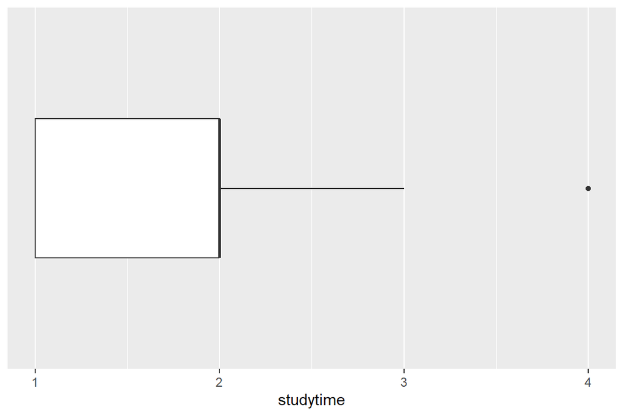

```r
alc_small %>%
  ggplot(aes(studytime)) +
  geom_boxplot() +
  scale_y_discrete(breaks = NULL, labels = NULL, name = NULL)
```

*Interpretations*

It appears as though the majority of students study between 1-5 hours a week (range of values 1 and 2). As for those who study above ten hours a week (value 4) it appears that these students are outliers in this dataset.

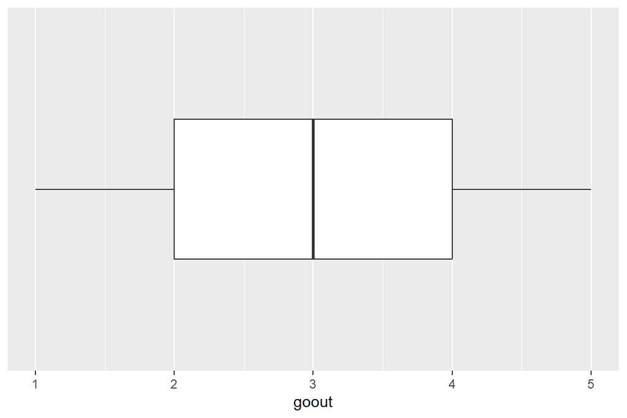

```r
alc_small %>%
  ggplot(aes(goout)) +
  geom_boxplot() +
  scale_y_discrete(breaks = NULL, labels = NULL, name = NULL)
```

*Interpretations*

Compared to the study time variable, it appears that the going out variable is normally distributed. The majority of students go out with their friends an average amount with the tails (very low and very high) following a normal bell curve.

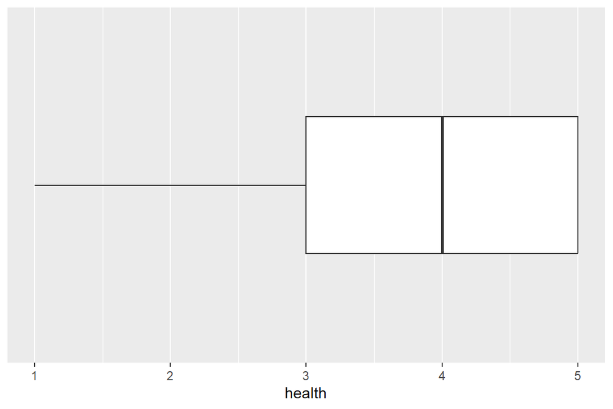

```r
alc_small %>%
  ggplot(aes(health)) +
  geom_boxplot() +
  scale_y_discrete(breaks = NULL, labels = NULL, name = NULL)
```

*Interpretations*

#### Count and Proportions

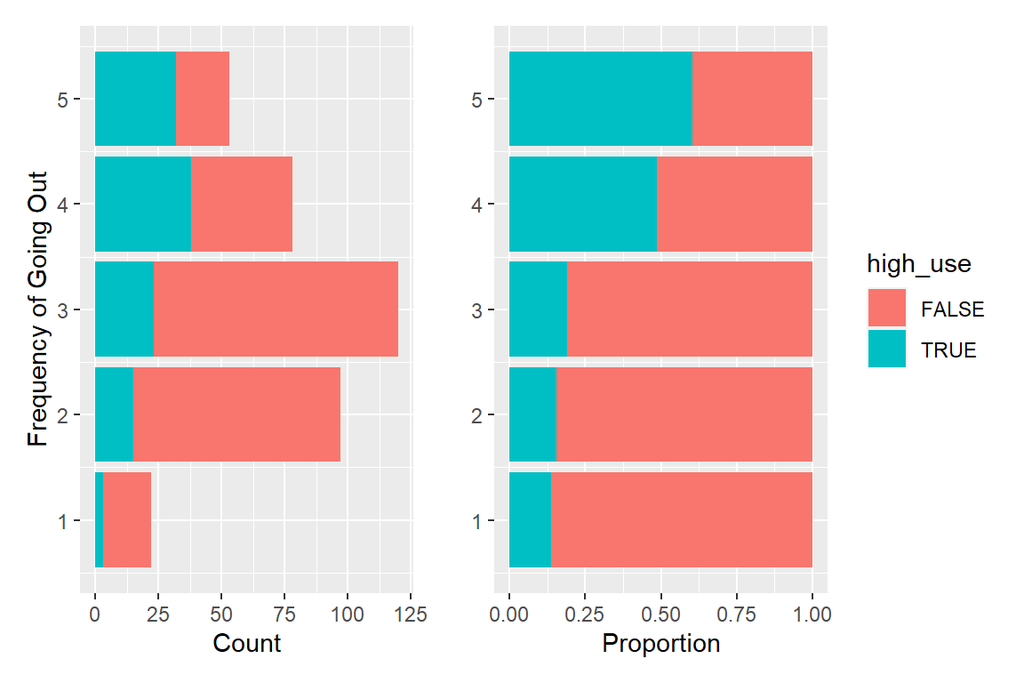

```r
p1 <- alc_small %>%
  ggplot(aes(x = goout,
             fill = high_use)) +
  geom_bar() +
  theme(legend.position="none")+
  coord_flip() +                               # flip for axis readability +
  labs(x = "Frequency of Going Out",           # label axes (flipped for coord-flip)
       y = "Count")

p2 <- alc_small %>%
  ggplot(aes(x = goout,
             fill = high_use,
             )) +
  geom_bar(position = "fill") +
  coord_flip() +                               # flip for axis readability
  theme(legend.position = NULL)+
  labs(x = "",                                 # label axes (flipped for coord-flip)
       y = "Proportion") +
  guides(fill = guide_legend(reverse = FALSE)) # reverse legend order

p1 + p2
```

*Interpretations*

From the proportion visualization, it is clear that those who are going out more often are more likely to have higher use of alcohol. A clear jump is seen between the frequency of 3 (average) and 4 (high). Perhaps this is because the majority of students answered that they see their friends an average amount and this large n evened out the results.

These results fall in line with my hypothesis that those students who go out more are have a higher probability of having higher levels of alcohol consumption.

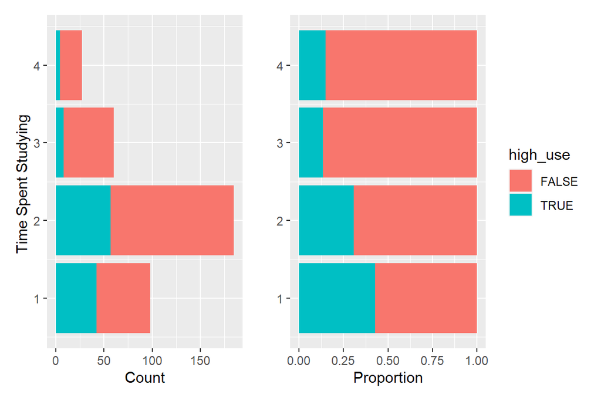

```r
p3 <- alc_small %>%
  ggplot(aes(x = studytime,
             fill = high_use)) +
  geom_bar() +
  theme(legend.position="none")+
  coord_flip() +                               # flip for axis readability +
  labs(x = "Time Spent Studying ",             # label axes (flipped for coord-flip)
       y = "Count")

p4 <- alc_small %>%
  ggplot(aes(x = studytime,
             fill = high_use,
             )) +
  geom_bar(position = "fill") +
  coord_flip() +                               # flip for axis readability
  theme(legend.position = NULL)+
  labs(x = "",                                 # label axes (flipped for coord-flip)
       y = "Proportion") +
  guides(fill = guide_legend(reverse = FALSE)) # reverse legend order

p3 + p4
```

*Interpretations*

Inverse to the going out variable, it appears that the more time one spends on one’s studies, the less likely one is to have higher levels of alcohol consumption. However, it should be noted that students who study more than 10 hours a week are outliers within this dataset and therefore the proportion is perhaps not representative.

These results align with my hypothesis that students who spent more time studying are less probable to consume alcohol at high levels.

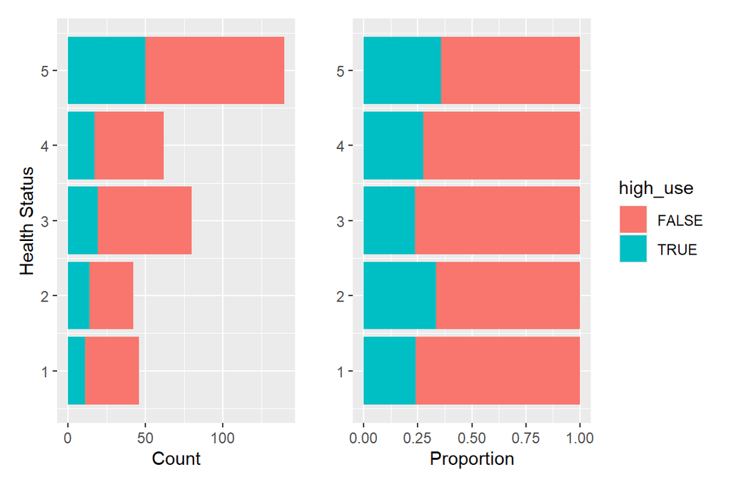

```r
p5 <- alc_small %>%
  ggplot(aes(x = health,
             fill = high_use)) +
  geom_bar() +
  theme(legend.position="none")+
  coord_flip() +                               # flip for axis readability +
  labs(x = "Health Status",                    # label axes (flipped for coord-flip)
       y = "Count")

p6 <- alc_small %>%
  ggplot(aes(x = health,
             fill = high_use,
             )) +
  geom_bar(position = "fill") +
  coord_flip() +                               # flip for axis readability
  theme(legend.position = NULL)+
  labs(x = "",                                 # label axes (flipped for coord-flip)
       y = "Proportion") +
  guides(fill = guide_legend(reverse = FALSE)) # reverse legend order

p5 + p6
```

*Interpretations*

Compared to the other two variables, health shows no trend when it comes to the relationship between health status and alcohol consumption. This makes sense as it was the only variable which did not possess a significant p-value (p=0.134).

These results do not fit my hypothesis as I thought that those with worse health (1 = very bad) would drink less than those with good health (5 = very good). Therefore, this hypothesis will be rejected.

#### Relationship

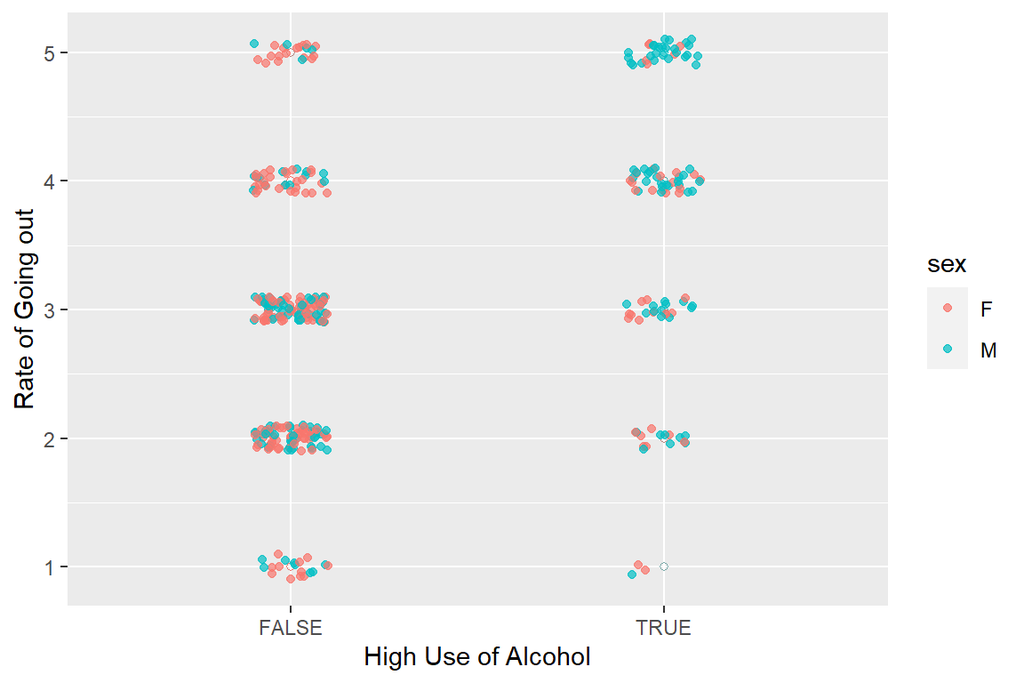

```r
p1 <- alc_small%>%
    ggplot(aes(x = high_use,
               y =goout,
               col = sex)) +
    geom_point(shape = 1, alpha = 0.5) +
    geom_jitter(width = 0.1, height = 0.1, alpha = 0.7) +
    labs(x = "High Use of Alcohol",
         y = "Rate of Going out")

p2 <- alc_small%>%
    ggplot(aes(x = high_use,
               y = studytime,
               col = sex)) +
    geom_point(shape = 1, alpha = 0.5) +
    geom_jitter(width = 0.1, height = 0.1, alpha = 0.7) +
    labs(x = "High Use of Alcohol",
         y = "Time Spent Studying")
p3 <- alc_small%>%
      ggplot(aes(x = high_use,
                 y = health,
                 col = sex)) +
      geom_jitter(width = 0.1, height = 0.1, alpha = 0.7) +
      labs(x = "High Use of Alcohol",
           y = "Current Health Condition")

p1
```

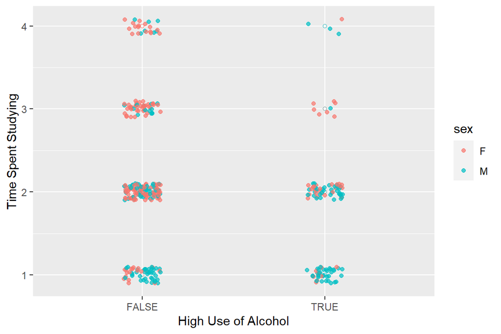

```r
p2
```

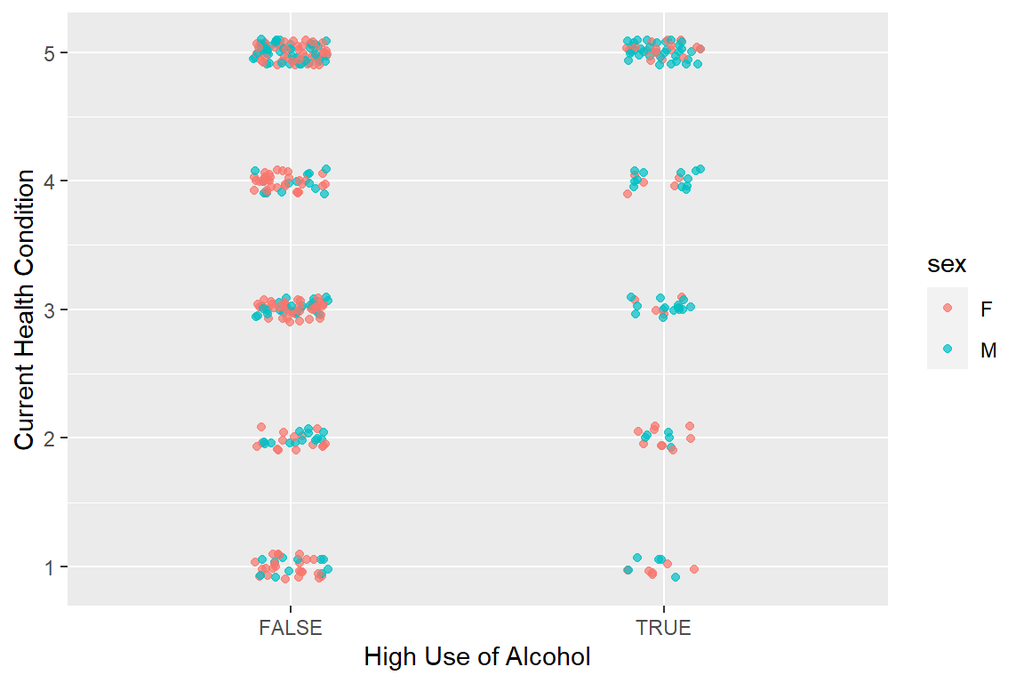

```r
p3
```

*Interpretations*

Like the above visualizations, this one confirms the hypotheses regarding going out and study time, but rejects the third related to health. These hypotheses are confirmed through observing the clustering of points. As this visualization adds the sex dimension, it is interesting to see if any observations regarding the relationship between alcohol use and sex can be made.

From the rate of going out visualization it appears to be that those who have high-use and go out very often are largely male. This can also be observed in the group of those who go out quite often. For the second visualization, it appears that those who study less than two hours a week and have a high-use are more likely to be male. Finally, for the third visualization no clear patterns in sex are present.

Due to over-fitting it is quite hard to see from this visualization what role sex might play in high alcohol use. Therefore, I will move on to the logistic regression section of this report to examine this hypothesis in more detail.

## Step 4: Logistic Regression

### Model Creation

```r
model1 <- glm(high_use ~ goout + studytime + health + sex, data = alc_small, family = "binomial")
```

### Model Summary

```r
summary(model1)
```

```
##
## Call:
## glm(formula = high_use ~ goout + studytime + health + sex, family = "binomial",
##     data = alc_small)
##
## Deviance Residuals:
##     Min       1Q   Median       3Q      Max
## -1.7958  -0.8199  -0.5074   0.8266   2.6553
##
## Coefficients:
##             Estimate Std. Error z value Pr(>|z|)
## (Intercept) -3.08085    0.66722  -4.617 3.88e-06 ***
## goout        0.75535    0.11995   6.297 3.03e-10 ***
## studytime   -0.49173    0.16972  -2.897  0.00376 **
## health       0.10173    0.09144   1.113  0.26588
## sexM         0.67717    0.26542   2.551  0.01073 *
## ---
## Signif. codes:  0 '***' 0.001 '**' 0.01 '*' 0.05 '.' 0.1 ' ' 1
##
## (Dispersion parameter for binomial family taken to be 1)
##
##     Null deviance: 452.04  on 369  degrees of freedom
## Residual deviance: 378.52  on 365  degrees of freedom
## AIC: 388.52
##
## Number of Fisher Scoring iterations: 4
```

*Interpretations*

From the coefficients we can see that the effect of going out on high alcohol use is an increase in the risk for high-alcohol use with the more on goes out (0,75535). For study time, as it is negative coefficient, for each increase in time spent studying there will be a reduction in the risk for high alcohol use (-0.49173). As for health, there is no significant effect. Finally, for sex, if the sex is male it will result in a risk increase (0.67717).

### Coefficients and Odds Ratios

```r
# compute odds ratios (OR)
OR <- coef(model1) %>% exp

# compute confidence intervals (CI)
CI <- confint(model1) %>% exp
# print out the odds ratios with their confidence intervals
cbind(OR, CI)
```

```
##                     OR      2.5 %    97.5 %
## (Intercept) 0.04592009 0.01197811 0.1648997
## goout       2.12835997 1.69321221 2.7127268
## studytime   0.61156896 0.43389780 0.8459784
## health      1.10708915 0.92679412 1.3275397
## sexM        1.96828985 1.17240926 3.3264016
```

*Interpretations*

Below, the odds ratio and the confidence interval difference can be seen. The confidence interval difference represents the range which is represented within the 95% confidence interval.

| Variable | OR | Confidence Interval Difference |
| --- | --- | --- |
| Going out | 2.13 | 1.02 (1.01951459) |
| Study Time | 0.61 | 0.41 (0.4120806) |
| Health | 1.11 | 0.40 (0.40074558) |
| Sex | 1.97 | 2.15 (2.15400134) |

## Step 5: Predictive power

Using the variables which, according to your logistic regression model, had a statistical relationship with high/low alcohol consumption, explore the predictive power of you model.

#### Model Creation

```r
final_model <- glm(high_use ~ goout + studytime + sex, data = alc_small, family = "binomial")
```

Provide a 2x2 cross tabulation of predictions versus the actual values and optionally display a graphic visualizing both the actual values and the predictions.

#### Cross tabulations: Predicted vs Actual

##### Numerical

```r
# predict() the probability of high_use
probabilities <- predict(final_model, type = "response")

# add the predicted probabilities to 'alc_small'
alc_small <- mutate(alc_small, probability = probabilities)

# use the probabilities to make a prediction of high_use
alc_small <- mutate(alc_small, prediction = alc_small$probability > 0.5)

# tabulate the target variable versus the predictions
table(high_use = alc_small$high_use, prediction = alc_small$prediction)
```

```
##         prediction
## high_use FALSE TRUE
##    FALSE   234   25
##    TRUE     58   53
```

##### Total Training Error

proportion = `(false positive + false negative)/n`

proportion = `(25 + 58)/370`

proportion = 0.2243

```r
confusionMatrix(
  factor(alc_small$prediction),
  factor(alc_small$high_use))
```

```
## Confusion Matrix and Statistics
##
##           Reference
## Prediction FALSE TRUE
##      FALSE   234   58
##      TRUE     25   53
##
##                Accuracy : 0.7757
##                  95% CI : (0.7297, 0.8172)
##     No Information Rate : 0.7
##     P-Value [Acc > NIR] : 0.0006928
##
##                   Kappa : 0.4163
##
##  Mcnemar's Test P-Value : 0.0004440
##
##             Sensitivity : 0.9035
##             Specificity : 0.4775
##          Pos Pred Value : 0.8014
##          Neg Pred Value : 0.6795
##              Prevalence : 0.7000
##          Detection Rate : 0.6324
##    Detection Prevalence : 0.7892
##       Balanced Accuracy : 0.6905
##
##        'Positive' Class : FALSE
##
```

*Interpretations*

Although I am not at the point where I can interpret the other outputs (Kappa, Sensitivity etc.), I hope to reach there one day!

##### Graphical

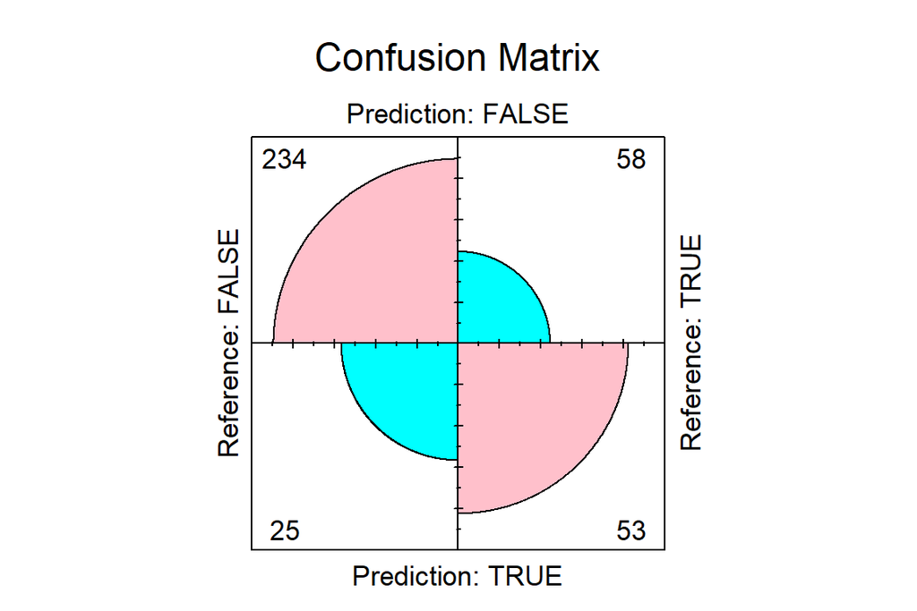

```r
# create confusion matrix
cmat <- confusionMatrix(
  factor(alc_small$prediction),
  factor(alc_small$high_use))

# visualize confusion matrix
fourfoldplot(cmat$table, color = c("cyan", "pink"),
             conf.level = 0, margin = 1, main = "Confusion Matrix")
```

*Final Interpretations and Model/Hypotheses Comparison*

A generous reading of the confusion matrix and the performance of the model would say that the model predicts false values correctly 9/10 of the time and positive values correctly 1/2 of the time. I do not believe that my simple guessing strategies would be able to reach this level of accuracy. When guessing, I often rely on broad generalizations (those who go out must drink more) to reach my conclusions. My hypotheses were thus oversimplified and did not reveal the nuance in the data. A clear example was that those who go out often have a 50% chance of having high alcohol use or not. Therefore, in order to reach the model accuracy, I would need to take more factors into account during my guessing. Yes, it is true that male students do drink more but is how much they drink proportionally to their weight taken into account? Therefore, while a simple guessing strategy can perhaps point the researcher which way to look, I do not think it can predict results as accurately as a well-built model can.

# Week 4 - Clustering and Classification

I have never worked with clustering or classification before this week. Therefore, it was incredibly challenging and I really struggled to understand how to interpret these results. I am not really sure why we used this set of this data set to understand crime when the data was related to housing values. Why not use it to look at housing values? I still am not really sure what the two clusters in the final output really represent, any good resources for interpretation would be appreciated!

```r
date()
```

```
## [1] "Mon Dec 12 22:09:59 2022"
```

# Assignment 4: Clustering and Classification

## Relevant Libraries and Packages

```r
library(MASS)
library(tidyr)
library(corrplot)
library(tidyverse)
library(ggplot2)
library(lattice)    # for box plots
library(reshape2)   # converting data to long format
library(factoextra) # k-means visualization
library(ggpubr)     # k-means visualization
library(GGally)     # ggpairs
```

## Step 1: Reading in the Data

```r
# load the data
data(Boston)

# explore the data set
str(Boston)
```

```
## 'data.frame':    506 obs. of  14 variables:
##  $ crim   : num  0.00632 0.02731 0.02729 0.03237 0.06905 ...
##  $ zn     : num  18 0 0 0 0 0 12.5 12.5 12.5 12.5 ...
##  $ indus  : num  2.31 7.07 7.07 2.18 2.18 2.18 7.87 7.87 7.87 7.87 ...
##  $ chas   : int  0 0 0 0 0 0 0 0 0 0 ...
##  $ nox    : num  0.538 0.469 0.469 0.458 0.458 0.458 0.524 0.524 0.524 0.524 ...
##  $ rm     : num  6.58 6.42 7.18 7 7.15 ...
##  $ age    : num  65.2 78.9 61.1 45.8 54.2 58.7 66.6 96.1 100 85.9 ...
##  $ dis    : num  4.09 4.97 4.97 6.06 6.06 ...
##  $ rad    : int  1 2 2 3 3 3 5 5 5 5 ...
##  $ tax    : num  296 242 242 222 222 222 311 311 311 311 ...
##  $ ptratio: num  15.3 17.8 17.8 18.7 18.7 18.7 15.2 15.2 15.2 15.2 ...
##  $ black  : num  397 397 393 395 397 ...
##  $ lstat  : num  4.98 9.14 4.03 2.94 5.33 ...
##  $ medv   : num  24 21.6 34.7 33.4 36.2 28.7 22.9 27.1 16.5 18.9 ...
```

```r
dim(Boston)
```

```
## [1] 506  14
```

*Explanations*

Containing data on housing values in suburbs of Boston, this data set consists of 14 columns and 506 rows. Each variable can be considered one which influences housing value in these suburbs. Explanations for each of the variables can be seen below:

| Variable Name | Variable Type | Explanation |
| --- | --- | --- |
| crim | numeric | per capita crime rate by town |
| zn | numeric | proportion of residential land zoned for lots over 25,000 sq.ft |
| indus | numeric | proportion of non-retail business acres per town |
| chas | integer | Charles River dummy variable (= 1 if tract bounds river; 0 otherwise). |
| nox | numeric | nitrogen oxides concentration (parts per 10 million) |
| rm | numeric | average number of rooms per dwelling. |
| age | numeric | proportion of owner-occupied units built prior to 1940 |
| dis | numeric | weighted mean of distances to five Boston employment centres |
| rad | integer | index of accessibility to radial highways |
| tax | numeric | full-value property-tax rate per $10,000 |
| ptratio | numeric | pupil-teacher ratio by town |
| black | numeric | 1000(Bk−0.63)2 where Bk is the proportion of blacks by town |
| lstat | numeric | lower status of the population (percent) |
| medv | numeric | median value of owner-occupied homes in $1000s |

## Step 2: Graphical and Numerical Exploration

### Graphical Overview

#### Boxplots

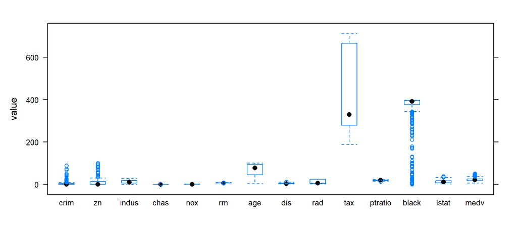

```r
# convert data to long format
Boston_long <- melt(Boston)

# create boxplot for all variables
bwplot(value ~ variable, Boston_long)
```

*Interpretations*

From this initial visualization it is clear that at least three variables (crim, zn and black) posses large numbers of outliers. However, due to the massive variance in scale across variables this is not an effective visualization. Therefore, the variables’ distributions will be visualized in smaller box plot groups.

As we are interested in the variables distributions, we will create a data set containing those which are closest in scale and then visualize those.

```r
# remove columns with largest scale variance
box_boston = subset(Boston, select = -c(tax,black))
```

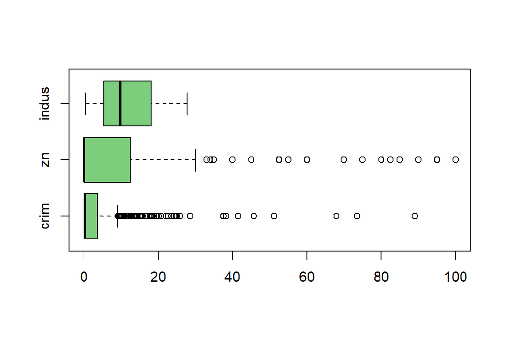

```r
boxplot(box_boston[1:3], col = "palegreen3", horizontal = TRUE)
```

*Interpretations*

A closer look at these boxplots confirms what was shown in the larger plot above. “Crim” and “zn” both possess many outliers and the distributions appear to be skewed to the right. Comparatively, “indus” seems to be distributed more evenly, although it appears to be left-leaning.

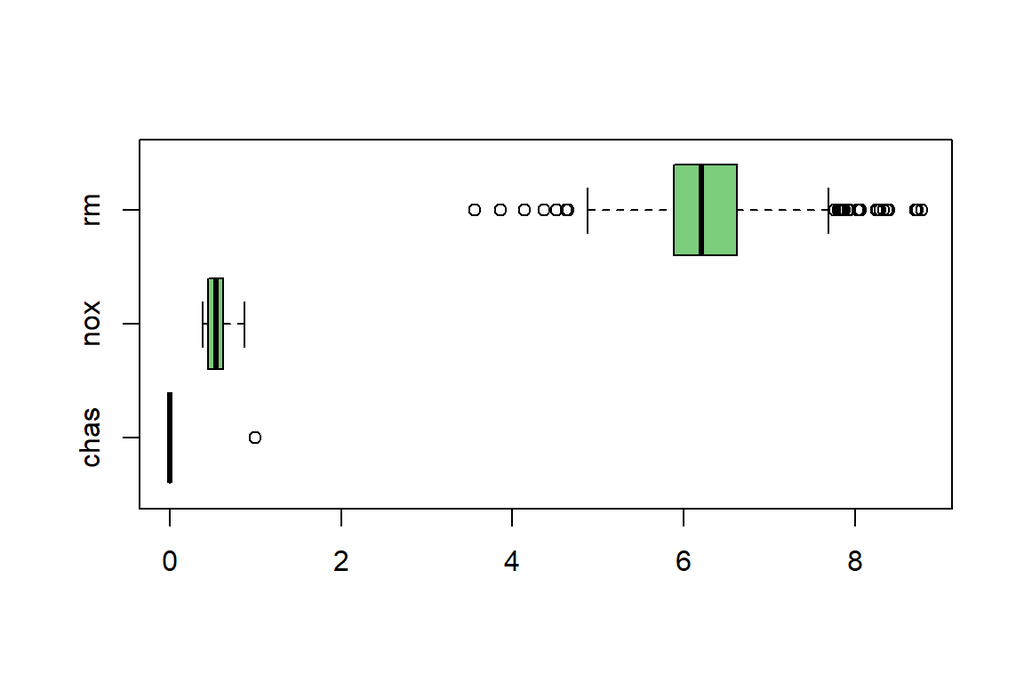

```r
boxplot(box_boston[4:6],  col = "palegreen3", horizontal = TRUE)
```

*Interpretations*

Above, we can see that “rm” possesses quite a few outliers with large tails on both sides of the distribution. Due to scale variance, it is hard to see the distribution of “nox” clearly. Despite this, it can appears to be left-leaning. “Chas” is a dummy variable, it’s value is either 0-1 and is therefore not suited well to box plot visualization.

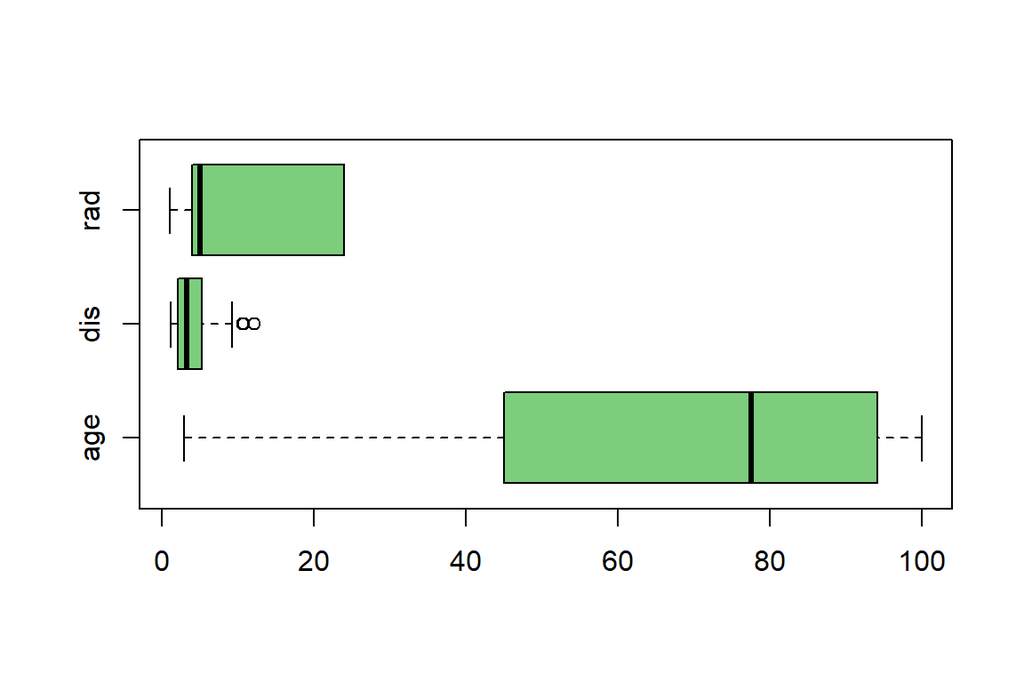

```r
boxplot(box_boston[7:9], col = "palegreen3", horizontal = TRUE)
```

*Interpretations*

“Rad” is a right-leaning distribution. It seems that the average house has has an index of access 10 to the radial highway. As for age, it appears as though around 70% of the buildings in these suburbs were built prior to 1940. The distribution has long tails which makes sense since it is in percent format. For “dis” some outliers appear on the right tail of the data.

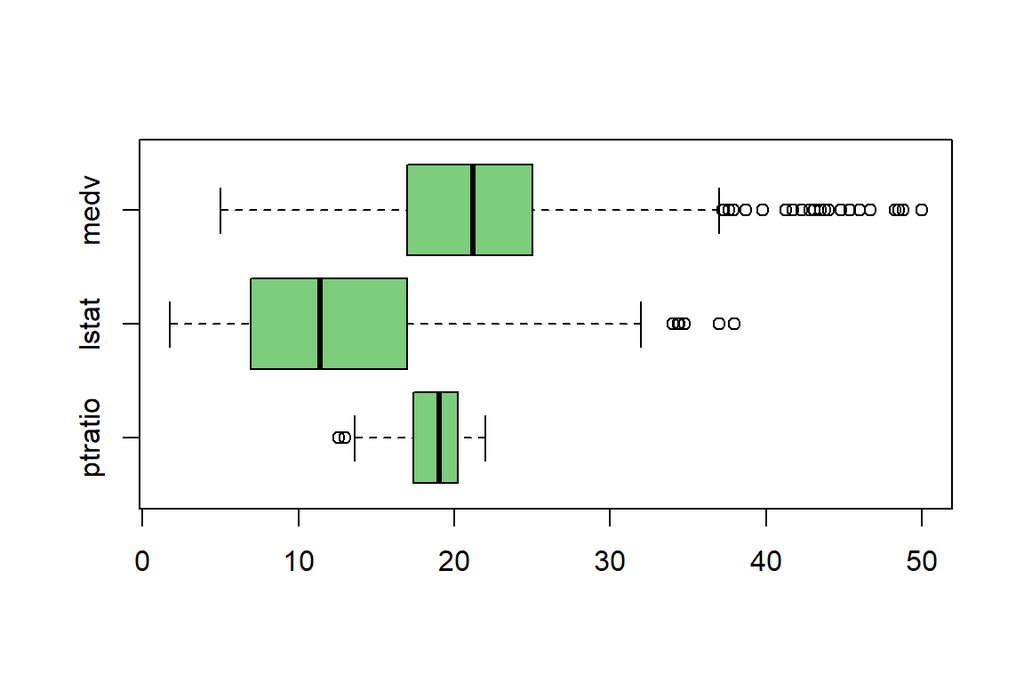

```r
boxplot(box_boston[10:12], col = "palegreen3", horizontal = TRUE)
```

*Interpretations*

“Medv” seems to possess quite a few outliers, with an average around 20, meaning that the average median for owner occupied homes is around 20,000$. “Lstat”also possess some outliers and appears to be left leaning. There seems to be an average of 14% of lower-status population in these suburbs (although I am not entirely sure what “lower-status population” refers to). Ptratio” seems to have a right-leaning distribution with a few outliers on the left tail.

#### Relationship

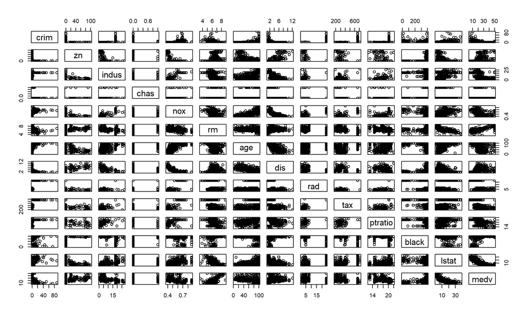

```r
pairs(Boston)
```

*Interpretations*

As this data uses such varying scales it is tough to comment on the relationship between variables in a meaningful way before scaling the data. However, from this scatterplot matrix it can be see that there appears to be a positive relationship between “rm” and “medv”. This makes intuitive sense as the more rooms a house has, the higher value it should be. “Rm” also seems to have a negative relationship with “lstat”, meaning that the higher the percentage lower-status population, the lower the average numer of rooms per home.

*Note:* For some reason I cannot get this visualization to knit in a way where it can be seen properly. If whoever is reading this knows how to format large visualizations like this for knitting, please let me know!

### Numerical Overview

#### Summaries

```r
summary(round(Boston, digits = 2))
```

```
##       crim              zn             indus            chas
##  Min.   : 0.010   Min.   :  0.00   Min.   : 0.46   Min.   :0.00000
##  1st Qu.: 0.080   1st Qu.:  0.00   1st Qu.: 5.19   1st Qu.:0.00000
##  Median : 0.255   Median :  0.00   Median : 9.69   Median :0.00000
##  Mean   : 3.613   Mean   : 11.36   Mean   :11.14   Mean   :0.06917
##  3rd Qu.: 3.678   3rd Qu.: 12.50   3rd Qu.:18.10   3rd Qu.:0.00000
##  Max.   :88.980   Max.   :100.00   Max.   :27.74   Max.   :1.00000
##       nox               rm             age              dis
##  Min.   :0.3800   Min.   :3.560   Min.   :  2.90   Min.   : 1.130
##  1st Qu.:0.4500   1st Qu.:5.883   1st Qu.: 45.02   1st Qu.: 2.100
##  Median :0.5400   Median :6.210   Median : 77.50   Median : 3.210
##  Mean   :0.5542   Mean   :6.285   Mean   : 68.57   Mean   : 3.795
##  3rd Qu.:0.6200   3rd Qu.:6.620   3rd Qu.: 94.08   3rd Qu.: 5.188
##  Max.   :0.8700   Max.   :8.780   Max.   :100.00   Max.   :12.130
##       rad              tax           ptratio          black
##  Min.   : 1.000   Min.   :187.0   Min.   :12.60   Min.   :  0.32
##  1st Qu.: 4.000   1st Qu.:279.0   1st Qu.:17.40   1st Qu.:375.38
##  Median : 5.000   Median :330.0   Median :19.05   Median :391.44
##  Mean   : 9.549   Mean   :408.2   Mean   :18.46   Mean   :356.67
##  3rd Qu.:24.000   3rd Qu.:666.0   3rd Qu.:20.20   3rd Qu.:396.23
##  Max.   :24.000   Max.   :711.0   Max.   :22.00   Max.   :396.90
##      lstat            medv
##  Min.   : 1.73   Min.   : 5.00
##  1st Qu.: 6.95   1st Qu.:17.02
##  Median :11.36   Median :21.20
##  Mean   :12.65   Mean   :22.53
##  3rd Qu.:16.95   3rd Qu.:25.00
##  Max.   :37.97   Max.   :50.00
```

*Interpretations*

Results from the numerical summary confirm the distributions which were visualized graphically above. Each variable has a varying scale which makes it hard to compare means across variables. However, we can see that both “tax” and “black” have large ranges which confirm their respective boxplots seen in the first visualization.

To make the data more comparable we will now standardize the data set.

### Step 3: Standardize data set & variable creation

#### Standardize

```r
# center and standardize variables
boston_scaled <- scale(Boston)

# summaries of the scaled variables
summary(boston_scaled)
```

```
##       crim                 zn               indus              chas
##  Min.   :-0.419367   Min.   :-0.48724   Min.   :-1.5563   Min.   :-0.2723
##  1st Qu.:-0.410563   1st Qu.:-0.48724   1st Qu.:-0.8668   1st Qu.:-0.2723
##  Median :-0.390280   Median :-0.48724   Median :-0.2109   Median :-0.2723
##  Mean   : 0.000000   Mean   : 0.00000   Mean   : 0.0000   Mean   : 0.0000
##  3rd Qu.: 0.007389   3rd Qu.: 0.04872   3rd Qu.: 1.0150   3rd Qu.:-0.2723
##  Max.   : 9.924110   Max.   : 3.80047   Max.   : 2.4202   Max.   : 3.6648
##       nox                rm               age               dis
##  Min.   :-1.4644   Min.   :-3.8764   Min.   :-2.3331   Min.   :-1.2658
##  1st Qu.:-0.9121   1st Qu.:-0.5681   1st Qu.:-0.8366   1st Qu.:-0.8049
##  Median :-0.1441   Median :-0.1084   Median : 0.3171   Median :-0.2790
##  Mean   : 0.0000   Mean   : 0.0000   Mean   : 0.0000   Mean   : 0.0000
##  3rd Qu.: 0.5981   3rd Qu.: 0.4823   3rd Qu.: 0.9059   3rd Qu.: 0.6617
##  Max.   : 2.7296   Max.   : 3.5515   Max.   : 1.1164   Max.   : 3.9566
##       rad               tax             ptratio            black
##  Min.   :-0.9819   Min.   :-1.3127   Min.   :-2.7047   Min.   :-3.9033
##  1st Qu.:-0.6373   1st Qu.:-0.7668   1st Qu.:-0.4876   1st Qu.: 0.2049
##  Median :-0.5225   Median :-0.4642   Median : 0.2746   Median : 0.3808
##  Mean   : 0.0000   Mean   : 0.0000   Mean   : 0.0000   Mean   : 0.0000
##  3rd Qu.: 1.6596   3rd Qu.: 1.5294   3rd Qu.: 0.8058   3rd Qu.: 0.4332
##  Max.   : 1.6596   Max.   : 1.7964   Max.   : 1.6372   Max.   : 0.4406
##      lstat              medv
##  Min.   :-1.5296   Min.   :-1.9063
##  1st Qu.:-0.7986   1st Qu.:-0.5989
##  Median :-0.1811   Median :-0.1449
##  Mean   : 0.0000   Mean   : 0.0000
##  3rd Qu.: 0.6024   3rd Qu.: 0.2683
##  Max.   : 3.5453   Max.   : 2.9865
```

```r
# class of the boston_scaled object
class(boston_scaled)
```

```
## [1] "matrix" "array"
```

```r
# change the object to data frame
boston_scaled <- as.data.frame(boston_scaled)
```

*Interpretations*

After standardizing, we can see that many variable values have become negative. The maximum values are also much closer across all variables. This step is crucial to perform Linear Discriminant Analysis (LDA) as LDA works under the assumption that each of the predictor variables have the same variance.

#### Categorical variable creation

```r
# create a quantile vector of crim
bins <- quantile(boston_scaled$crim)

# create a categorical variable 'crime'
crime <- cut(boston_scaled$crim,
             breaks = bins,
             include.lowest = TRUE,
             labels = c("low", "med_low", "med_high", "high"))

# remove original crim from the dataset
boston_scaled <- dplyr::select(boston_scaled, -crim)

# add the new categorical value to scaled data
boston_scaled <- data.frame(boston_scaled, crime)
```

#### Train and Test set

```r
boston_scaled$crime <- factor(boston_scaled$crime,
                              levels = c("low",
                                         "med_low",
                                         "med_high",
                                         "high"))

# choose randomly 80% of the rows in data set
ind <- sample(nrow(boston_scaled),  size = nrow(boston_scaled) * 0.8)

# create train set
train <- boston_scaled[ind,]

# create test set
test <- boston_scaled[-ind,]
```

## Step 4: Linear Discriminant Analysis

```r
# linear discriminant analysis
lda.fit <- lda(crime ~ ., data = train)

# the function for lda biplot arrows
lda.arrows <- function(x, myscale = 1, arrow_heads = 0.1, color = "red", tex = 0.75, choices = c(1,2)){
  heads <- coef(x)
  arrows(x0 = 0, y0 = 0,
         x1 = myscale * heads[,choices[1]],
         y1 = myscale * heads[,choices[2]], col=color, length = arrow_heads)
  text(myscale * heads[,choices], labels = row.names(heads),
       cex = tex, col=color, pos=3)
}

# target classes as numeric
classes <- as.numeric(train$crime)

# plot the lda results
plot(lda.fit, dimen = 2, col = classes, pch = classes)
lda.arrows
```

```
## function(x, myscale = 1, arrow_heads = 0.1, color = "red", tex = 0.75, choices = c(1,2)){
##   heads <- coef(x)
##   arrows(x0 = 0, y0 = 0,
##          x1 = myscale * heads[,choices[1]],
##          y1 = myscale * heads[,choices[2]], col=color, length = arrow_heads)
##   text(myscale * heads[,choices], labels = row.names(heads),
##        cex = tex, col=color, pos=3)
## }
```

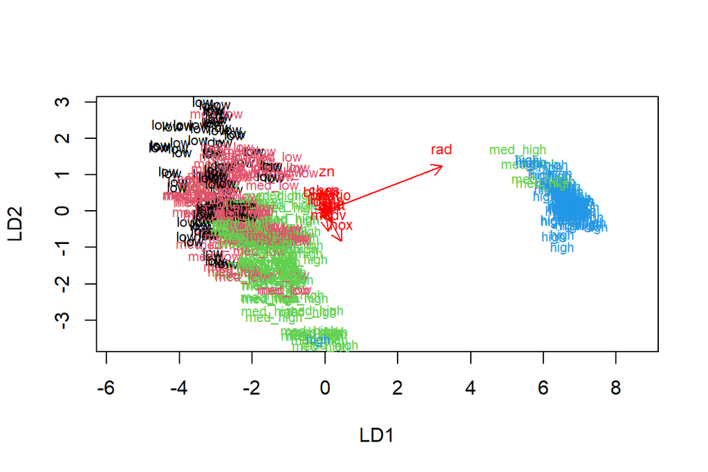

```r
lda.arrows(lda.fit, myscale = 1)
```

*Interpretations*

From the length of the arrows we can see that “rad”, “nox”, and “zn” have the largest variation in the data set.Unfortunately, due to overlapping values it is hard to interpret the angles- which represent the relationship - between the arrows. Despite these difficulties, a potential right-angle can be seen between “rad” and “nox” meaning that they are not highly correlated.

## Step 5: Cross Tabulation

```r
# save the correct classes from test data
correct_classes <- test$crime

# remove the crime variable from test data
test <- dplyr::select(test, -crime)

# predict classes with test data
lda.pred <- predict(lda.fit, newdata = test)

# cross tabulate the results
table(correct = correct_classes, predicted = lda.pred$class)
```

```
##           predicted
## correct    low med_low med_high high
##   low       13       9        2    0
##   med_low    2      17        8    0
##   med_high   0      12       12    2
##   high       0       0        0   25
```

*Interpretations*

We can calculate the accuracy of the model following:

$$Accuracy = \frac{\text{Number of correct predictions}}{\text{Total
number of predictions}}$$